# Capstone Project: Create a Customer Segmentation Report for Arvato Financial Services

In this project, you will analyze demographics data for customers of a mail-order sales company in Germany, comparing it against demographics information for the general population. You'll use unsupervised learning techniques to perform customer segmentation, identifying the parts of the population that best describe the core customer base of the company. Then, you'll apply what you've learned on a third dataset with demographics information for targets of a marketing campaign for the company, and use a model to predict which individuals are most likely to convert into becoming customers for the company. The data that you will use has been provided by our partners at Bertelsmann Arvato Analytics, and represents a real-life data science task.

If you completed the first term of this program, you will be familiar with the first part of this project, from the unsupervised learning project. The versions of those two datasets used in this project will include many more features and has not been pre-cleaned. You are also free to choose whatever approach you'd like to analyzing the data rather than follow pre-determined steps. In your work on this project, make sure that you carefully document your steps and decisions, since your main deliverable for this project will be a blog post reporting your findings.

```python
# import libraries here; add more as necessary
import numpy as np
import pandas as pd
import matplotlib.pyplot as plt
import seaborn as sns
from sklearn.model_selection import GridSearchCV, train_test_split
import lightgbm as lgb
from sklearn.metrics import roc_auc_score
from sklearn.ensemble import RandomForestClassifier
from xgboost.sklearn import XGBRegressor
from sklearn.impute import SimpleImputer
from sklearn.preprocessing import StandardScaler
from sklearn.cluster import KMeans
#from pandas_profiling import ProfileReport

# magic word for producing visualizations in notebook
%matplotlib inline
plt.rcParams["figure.figsize"] = (18,8)

from IPython.core.display import display, HTML
display(HTML("<style>.container { width:100% !important; }</style>"))
np.set_printoptions(edgeitems=10)
np.core.arrayprint._line_width = 180
```

## Part 0: Get to Know the Data

Each row of the demographics files represents a single person, but also includes information outside of individuals, including information about their household, building, and neighborhood. Use the information from the first two files to figure out how customers ("CUSTOMERS") are similar to or differ from the general population at large ("AZDIAS"), then use your analysis to make predictions on the other two files ("MAILOUT"), predicting which recipients are most likely to become a customer for the mail-order company.

The "CUSTOMERS" file contains three extra columns ('CUSTOMER_GROUP', 'ONLINE_PURCHASE', and 'PRODUCT_GROUP'), which provide broad information about the customers depicted in the file. The original "MAILOUT" file included one additional column, "RESPONSE", which indicated whether or not each recipient became a customer of the company. For the "TRAIN" subset, this column has been retained, but in the "TEST" subset it has been removed; it is against that withheld column that your final predictions will be assessed in the Kaggle competition.

Otherwise, all of the remaining columns are the same between the three data files. For more information about the columns depicted in the files, you can refer to two Excel spreadsheets provided in the workspace. One of them is a top-level list of attributes and descriptions, organized by informational category. The other is a detailed mapping of data values for each feature in alphabetical order.

In the below cell, we've provided some initial code to load in the first two datasets. Note for all of the `.csv` data files in this project that they're semicolon (`;`) delimited, so an additional argument in the [`read_csv()`](https://pandas.pydata.org/pandas-docs/stable/generated/pandas.read_csv.html) call has been included to read in the data properly. Also, considering the size of the datasets, it may take some time for them to load completely.

You'll notice when the data is loaded in that a warning message will immediately pop up. Before you really start digging into the modeling and analysis, you're going to need to perform some cleaning. Take some time to browse the structure of the data and look over the informational spreadsheets to understand the data values. Make some decisions on which features to keep, which features to drop, and if any revisions need to be made on data formats. It'll be a good idea to create a function with pre-processing steps, since you'll need to clean all of the datasets before you work with them.

```python
%%time
#Load AZDIAS and get summary stats

azdias = pd.read_csv('arvato_data/Udacity_AZDIAS_052018.csv',  dtype={18:'str',19:'str'}, sep=';')
print(azdias.info())
print(azdias.describe())
```

```
<class 'pandas.core.frame.DataFrame'>
RangeIndex: 891221 entries, 0 to 891220
Columns: 366 entries, LNR to ALTERSKATEGORIE_GROB
dtypes: float64(267), int64(93), object(6)
memory usage: 2.4+ GB
None
                LNR       AGER_TYP     AKT_DAT_KL       ALTER_HH  \
count  8.912210e+05  891221.000000  817722.000000  817722.000000
mean   6.372630e+05      -0.358435       4.421928      10.864126
std    2.572735e+05       1.198724       3.638805       7.639683
min    1.916530e+05      -1.000000       1.000000       0.000000
25%    4.144580e+05      -1.000000       1.000000       0.000000
50%    6.372630e+05      -1.000000       3.000000      13.000000
75%    8.600680e+05      -1.000000       9.000000      17.000000
max    1.082873e+06       3.000000       9.000000      21.000000

        ALTER_KIND1   ALTER_KIND2  ALTER_KIND3  ALTER_KIND4  \
count  81058.000000  29499.000000  6170.000000  1205.000000
mean      11.745392     13.402658    14.476013    15.089627
std        4.097660      3.243300     2.712427     2.452932
min        2.000000      2.000000     4.000000     7.000000
25%        8.000000     11.000000    13.000000    14.000000
50%       12.000000     14.000000    15.000000    15.000000
75%       15.000000     16.000000    17.000000    17.000000
max       18.000000     18.000000    18.000000    18.000000

       ALTERSKATEGORIE_FEIN  ANZ_HAUSHALTE_AKTIV  ...            VHN  \
count         628274.000000        798073.000000  ...  770025.000000
mean              13.700717             8.287263  ...       2.417322
std                5.079849            15.628087  ...       1.166572
min                0.000000             0.000000  ...       0.000000
25%               11.000000             1.000000  ...       2.000000
50%               14.000000             4.000000  ...       2.000000
75%               17.000000             9.000000  ...       3.000000
max               25.000000           595.000000  ...       4.000000

            VK_DHT4A     VK_DISTANZ        VK_ZG11  W_KEIT_KIND_HH  \
count  815304.000000  815304.000000  815304.000000   783619.000000
mean        6.001214       7.532130       5.945972        3.933406
std         2.856091       3.247789       2.771464        1.964701
```

[output cut: 13 more lines]

```
75%          9.000000       5.000000       4.000000       2.000000
max          9.000000       8.000000       6.000000       2.000000

       ALTERSKATEGORIE_GROB
count         891221.000000
mean               2.777398
std                1.068775
min                1.000000
25%                2.000000
50%                3.000000
75%                4.000000
max                9.000000

[8 rows x 360 columns]
Wall time: 7min 58s
```

```python
#Get list of columns with mostly missing values
percent_missing = azdias.isna().mean().round(4) * 100
percent_missing.sort_values(inplace=True)
drop_list = percent_missing[percent_missing > 30.0 ]
print(drop_list)
#percent_missing.plot()
```

```
KK_KUNDENTYP    65.60
EXTSEL992       73.40
ALTER_KIND1     90.90
ALTER_KIND2     96.69
ALTER_KIND3     99.31
ALTER_KIND4     99.86
dtype: float64
```

```python
percent_missing_rows = azdias.isna().mean(axis=1).round(4) * 100
percent_missing_rows.sort_values(inplace=True)
percent_missing_rows[percent_missing_rows > 50.0 ].count()
```

```
99231
```

```python
corr_df = azdias.corr()
high_corr = corr_df.applymap(lambda x: abs(x) > 0.96)
a_list = high_corr.sum().sort_values()
high_corr_list = a_list[a_list > 1]
corr_df.loc[high_corr_list.index, high_corr_list.index]
```

|  | LP_LEBENSPHASE_GROB | LP_FAMILIE_GROB | LP_STATUS_FEIN | LP_STATUS_GROB | KBA13_GBZ | LP_LEBENSPHASE_FEIN | KBA13_FAB_SONSTIGE | KBA13_HHZ | ANZ_HAUSHALTE_AKTIV | PLZ8_GBZ | PLZ8_HHZ | KBA13_KMH_250 | KBA13_KMH_211 | KBA13_HERST_SONST | LP_FAMILIE_FEIN | ANZ_STATISTISCHE_HAUSHALTE |
| --- | --- | --- | --- | --- | --- | --- | --- | --- | --- | --- | --- | --- | --- | --- | --- | --- |
| LP_LEBENSPHASE_GROB | 1.000000 | 0.957661 | 0.390511 | 0.407881 | 0.153845 | 0.989961 | -0.069172 | -0.069047 | -0.177847 | 0.152153 | -0.064933 | -0.000401 | -0.000817 | -0.069172 | 0.942819 | -0.177903 |
| LP_FAMILIE_GROB | 0.957661 | 1.000000 | 0.234589 | 0.245960 | 0.109975 | 0.941647 | -0.058545 | -0.048613 | -0.129295 | 0.108347 | -0.046411 | -0.004564 | -0.004727 | -0.058545 | 0.984100 | -0.131622 |
| LP_STATUS_FEIN | 0.390511 | 0.234589 | 1.000000 | 0.982411 | 0.358554 | 0.443415 | -0.106164 | -0.122229 | -0.372640 | 0.356850 | -0.109888 | 0.038974 | 0.037655 | -0.106164 | 0.236180 | -0.367039 |
| LP_STATUS_GROB | 0.407881 | 0.245960 | 0.982411 | 1.000000 | 0.346147 | 0.463909 | -0.104668 | -0.107028 | -0.357599 | 0.344592 | -0.095378 | 0.051409 | 0.050484 | -0.104668 | 0.241076 | -0.351731 |
| KBA13_GBZ | 0.153845 | 0.109975 | 0.358554 | 0.346147 | 1.000000 | 0.178266 | -0.169633 | 0.475506 | -0.292483 | 0.979854 | 0.489083 | 0.127471 | 0.127423 | -0.169633 | 0.107839 | -0.286385 |
| LP_LEBENSPHASE_FEIN | 0.989961 | 0.941647 | 0.443415 | 0.463909 | 0.178266 | 1.000000 | -0.074396 | -0.074577 | -0.201056 | 0.176442 | -0.069709 | 0.004134 | 0.003681 | -0.074396 | 0.917662 | -0.200118 |
| KBA13_FAB_SONSTIGE | -0.069172 | -0.058545 | -0.106164 | -0.104668 | -0.169633 | -0.074396 | 1.000000 | 0.018634 | 0.063624 | -0.167843 | 0.023256 | -0.014234 | -0.012642 | 1.000000 | -0.059229 | 0.063293 |
| KBA13_HHZ | -0.069047 | -0.048613 | -0.122229 | -0.107028 | 0.475506 | -0.074577 | 0.018634 | 1.000000 | 0.094123 | 0.475023 | 0.968725 | 0.106656 | 0.109367 | 0.018634 | -0.047557 | 0.092390 |
| ANZ_HAUSHALTE_AKTIV | -0.177847 | -0.129295 | -0.372640 | -0.357599 | -0.292483 | -0.201056 | 0.063624 | 0.094123 | 1.000000 | -0.291662 | 0.086214 | -0.024765 | -0.023419 | 0.063624 | -0.125571 | 0.976900 |
| PLZ8_GBZ | 0.152153 | 0.108347 | 0.356850 | 0.344592 | 0.979854 | 0.176442 | -0.167843 | 0.475023 | -0.291662 | 1.000000 | 0.497958 | 0.126185 | 0.126570 | -0.167843 | 0.106649 | -0.285719 |
| PLZ8_HHZ | -0.064933 | -0.046411 | -0.109888 | -0.095378 | 0.489083 | -0.069709 | 0.023256 | 0.968725 | 0.086214 | 0.497958 | 1.000000 | 0.106652 | 0.109568 | 0.023256 | -0.045396 | 0.084674 |
| KBA13_KMH_250 | -0.000401 | -0.004564 | 0.038974 | 0.051409 | 0.127471 | 0.004134 | -0.014234 | 0.106656 | -0.024765 | 0.126185 | 0.106652 | 1.000000 | 0.960155 | -0.014234 | -0.003835 | -0.024525 |
| KBA13_KMH_211 | -0.000817 | -0.004727 | 0.037655 | 0.050484 | 0.127423 | 0.003681 | -0.012642 | 0.109367 | -0.023419 | 0.126570 | 0.109568 | 0.960155 | 1.000000 | -0.012642 | -0.003986 | -0.022973 |
| KBA13_HERST_SONST | -0.069172 | -0.058545 | -0.106164 | -0.104668 | -0.169633 | -0.074396 | 1.000000 | 0.018634 | 0.063624 | -0.167843 | 0.023256 | -0.014234 | -0.012642 | 1.000000 | -0.059229 | 0.063293 |
| LP_FAMILIE_FEIN | 0.942819 | 0.984100 | 0.236180 | 0.241076 | 0.107839 | 0.917662 | -0.059229 | -0.047557 | -0.125571 | 0.106649 | -0.045396 | -0.003835 | -0.003986 | -0.059229 | 1.000000 | -0.127050 |
| ANZ_STATISTISCHE_HAUSHALTE | -0.177903 | -0.131622 | -0.367039 | -0.351731 | -0.286385 | -0.200118 | 0.063293 | 0.092390 | 0.976900 | -0.285719 | 0.084674 | -0.024525 | -0.022973 | 0.063293 | -0.127050 | 1.000000 |

```python
# Functions to clean and preprocess datasets

drop_cols = ['LNR', 'KK_KUNDENTYP', 'ALTER_KIND1', 'ALTER_KIND2', 'ALTER_KIND3', 'ALTER_KIND4', 'EXTSEL992',
'CAMEO_DEU_2015', 'CAMEO_DEUG_2015', 'CAMEO_INTL_2015', 'D19_LETZTER_KAUF_BRANCHE', 'EINGEZOGENAM_HH_JAHR',
'EINGEFUEGT_AM', 'ALTERSKATEGORIE_FEIN', 'D19_WEIN_FEINKOST', 'PRAEGENDE_JUGENDJAHRE', 'EINGEFUEGT_AM',
'D19_VERSAND_ONLINE_DATUM', 'D19_VERSAND_DATUM', 'LP_FAMILIE_FEIN', 'LP_LEBENSPHASE_FEIN', 'LP_STATUS_FEIN',
'ANZ_STATISTISCHE_HAUSHALTE', 'D19_VERSAND_ANZ_24']

def clean_dataset(df):
    df.dropna(thresh=335, inplace=True)
    df.drop(drop_cols, axis=1, inplace=True)
    return(df)

def preprocess_data(df):
    # Replace east and west chars with numbers
    #df.loc[:, 'OST_WEST_KZ'].replace({'W':0, 'O':1}, inplace=True);

    imp = SimpleImputer(missing_values=float("NaN"), strategy="most_frequent", copy = False)
    processed_df = imp.fit_transform(df)

    s_scaler = StandardScaler()
    processed_df = pd.DataFrame(s_scaler.fit_transform(processed_df))
    processed_df.columns = df.columns

    return(pd.DataFrame(processed_df ))
```

```python
azdias.info()
clean_dataset(azdias)
azdias.info()
azdias.to_csv('arvato_data/AZDIAS_dropped.csv', sep=';')
```

```
<class 'pandas.core.frame.DataFrame'>
RangeIndex: 891221 entries, 0 to 891220
Columns: 366 entries, LNR to ALTERSKATEGORIE_GROB
dtypes: float64(267), int64(93), object(6)
memory usage: 2.4+ GB
<class 'pandas.core.frame.DataFrame'>
Int64Index: 750604 entries, 1 to 891220
Columns: 343 entries, AGER_TYP to ALTERSKATEGORIE_GROB
dtypes: float64(255), int64(87), object(1)
memory usage: 1.9+ GB
```

```python
azdias_preprocessed  = preprocess_data(azdias)
```

```python
# load in the data
customers = pd.read_csv('arvato_data/Udacity_CUSTOMERS_052018.csv',  dtype={18:'str',19:'str'}, sep=';')
# Drop the extra column of customers dataset.
customers.drop(columns=['CUSTOMER_GROUP', 'ONLINE_PURCHASE', 'PRODUCT_GROUP'], inplace=True)
```

```python
print(customers.shape)
print(customers.info())
print(customers.describe())
customers_missing_rows = customers.isna().mean(axis=1).round(4) * 100
customers_missing_rows.sort_values(inplace=True)
customers_missing_rows[customers_missing_rows > 80.0 ].count()
```

```
(191652, 366)
<class 'pandas.core.frame.DataFrame'>
RangeIndex: 191652 entries, 0 to 191651
Columns: 366 entries, LNR to ALTERSKATEGORIE_GROB
dtypes: float64(267), int64(93), object(6)
memory usage: 535.2+ MB
None
                 LNR       AGER_TYP     AKT_DAT_KL       ALTER_HH  \
count  191652.000000  191652.000000  145056.000000  145056.000000
mean    95826.500000       0.344359       1.747525      11.352009
std     55325.311233       1.391672       1.966334       6.275026
min         1.000000      -1.000000       1.000000       0.000000
25%     47913.750000      -1.000000       1.000000       8.000000
50%     95826.500000       0.000000       1.000000      11.000000
75%    143739.250000       2.000000       1.000000      16.000000
max    191652.000000       3.000000       9.000000      21.000000

        ALTER_KIND1  ALTER_KIND2  ALTER_KIND3  ALTER_KIND4  \
count  11766.000000  5100.000000  1275.000000   236.000000
mean      12.337243    13.672353    14.647059    15.377119
std        4.006050     3.243335     2.753787     2.307653
min        2.000000     2.000000     5.000000     8.000000
25%        9.000000    11.000000    13.000000    14.000000
50%       13.000000    14.000000    15.000000    16.000000
75%       16.000000    16.000000    17.000000    17.000000
max       18.000000    18.000000    18.000000    18.000000

       ALTERSKATEGORIE_FEIN  ANZ_HAUSHALTE_AKTIV  ...            VHN  \
count         139810.000000        141725.000000  ...  137392.000000
mean              10.331579             4.965863  ...       2.429508
std                4.134828            14.309694  ...       1.148821
min                0.000000             0.000000  ...       0.000000
25%                9.000000             1.000000  ...       2.000000
50%               10.000000             1.000000  ...       2.000000
75%               13.000000             4.000000  ...       3.000000
max               25.000000           523.000000  ...       4.000000

            VK_DHT4A     VK_DISTANZ        VK_ZG11  W_KEIT_KIND_HH  \
count  143781.000000  143781.000000  143781.000000   137910.000000
mean        4.374417       4.564769       3.168868        4.152716
```

[output cut: 13 more lines]

```
50%          9.000000       3.000000       3.000000       1.000000
75%          9.000000       5.000000       3.000000       2.000000
max          9.000000       8.000000       6.000000       2.000000

       ALTERSKATEGORIE_GROB
count         191652.000000
mean               3.060907
std                1.086254
min                1.000000
25%                3.000000
50%                3.000000
75%                4.000000
max                9.000000

[8 rows x 360 columns]
```

```
0
```

```python
customers.head()
customers_missing_rows = customers.isna().mean(axis=1).round(4) * 100
customers_missing_rows.sort_values(inplace=True)
print(customers_missing_rows[customers_missing_rows > 60.0 ].count())
```

```
49930
```

```python
customers.info()
clean_dataset(customers)
customers_preprocessed = preprocess_data(customers)
print(customers_preprocessed.info())
print(customers_preprocessed.head())
```

[output not shown]

```python
#azdias = pd.read_csv('arvato_data/AZDIAS_dropped.csv',  sep=';', index_col=0)
azdias_preprocessed = pd.read_csv('arvato_data/AZDIAS_cleaned.csv', sep=';')
azdias_preprocessed.drop(azdias_preprocessed.columns[0], axis=1, inplace=True)
print(azdias_preprocessed.info())
print(azdias_preprocessed.describe())
print(azdias_preprocessed.head())
```

```
<class 'pandas.core.frame.DataFrame'>
RangeIndex: 750604 entries, 0 to 750603
Columns: 343 entries, AGER_TYP to ALTERSKATEGORIE_GROB
dtypes: float64(343)
memory usage: 1.9 GB
None
```

```python
azdias_preprocessed
```

|  | AGER_TYP | AKT_DAT_KL | ALTER_HH | ANZ_HAUSHALTE_AKTIV | ANZ_HH_TITEL | ANZ_KINDER | ANZ_PERSONEN | ANZ_TITEL | ARBEIT | BALLRAUM | ... | VHN | VK_DHT4A | VK_DISTANZ | VK_ZG11 | W_KEIT_KIND_HH | WOHNDAUER_2008 | WOHNLAGE | ZABEOTYP | ANREDE_KZ | ALTERSKATEGORIE_GROB |
| --- | --- | --- | --- | --- | --- | --- | --- | --- | --- | --- | --- | --- | --- | --- | --- | --- | --- | --- | --- | --- | --- |
| 0 | -0.572979 | 1.249407 | -1.417136 | 0.159141 | -0.128334 | -0.296889 | 0.233213 | -0.060628 | -0.190359 | 0.851519 | ... | 1.367375 | 0.681651 | 1.055463 | 1.452298 | -0.601795 | 0.548461 | -0.028548 | 1.139257 | 0.957594 | -1.684810 |
| 1 | -0.572979 | 1.249407 | 0.809426 | 0.095291 | -0.128334 | -0.296889 | -0.626902 | -0.060628 | -0.190359 | -0.975355 | ... | -0.359341 | 1.031493 | 0.441258 | 0.018122 | -0.601795 | 0.548461 | -1.085614 | 1.139257 | 0.957594 | 0.164104 |
| 2 | 1.857962 | -0.942516 | 0.285529 | -0.479357 | -0.128334 | -0.296889 | -1.487017 | -0.060628 | -1.195149 | -0.061918 | ... | -2.086056 | 0.331809 | 0.748360 | 1.810842 | 0.981839 | 0.548461 | 1.557051 | -0.284771 | 0.957594 | 1.088562 |
| 3 | -0.572979 | -0.942516 | 1.202349 | -0.351657 | -0.128334 | -0.296889 | 1.953443 | -0.060628 | 0.814431 | -0.975355 | ... | -0.359341 | -1.067560 | -0.787153 | -0.698965 | -1.129672 | 0.548461 | -0.557081 | 0.427243 | -1.044283 | 0.164104 |
| 4 | 2.668276 | -0.942516 | -0.107394 | -0.223958 | -0.128334 | -0.296889 | -0.626902 | -0.060628 | -1.195149 | 0.851519 | ... | -0.359341 | 1.381336 | -0.172947 | -0.698965 | 0.981839 | 0.548461 | 1.557051 | 0.427243 | 0.957594 | -1.684810 |
| ... | ... | ... | ... | ... | ... | ... | ... | ... | ... | ... | ... | ... | ... | ... | ... | ... | ... | ... | ... | ... | ... |
| 750599 | -0.572979 | 0.153446 | 0.809426 | 0.414540 | -0.128334 | -0.296889 | -0.626902 | -0.060628 | 0.814431 | 0.851519 | ... | -0.359341 | -0.717718 | -0.172947 | 0.735210 | -0.601795 | -2.097491 | -0.557081 | 0.427243 | 0.957594 | 0.164104 |
| 750600 | -0.572979 | 1.249407 | 0.678452 | 0.159141 | -0.128334 | -0.296889 | -0.626902 | -0.060628 | 0.814431 | 1.308238 | ... | 1.367375 | -0.018033 | 0.441258 | 0.018122 | 0.981839 | 0.548461 | 0.499985 | 1.851272 | -1.044283 | -0.760353 |
| 750601 | -0.572979 | -0.942516 | 0.809426 | -0.351657 | -0.128334 | -0.296889 | -1.487017 | -0.060628 | -1.195149 | 0.394801 | ... | -0.359341 | 0.331809 | 0.748360 | 0.735210 | 0.981839 | -1.568300 | 1.557051 | 0.427243 | 0.957594 | -0.760353 |
| 750602 | -0.572979 | 1.249407 | -1.417136 | -0.096258 | -0.128334 | 1.763484 | -0.626902 | -0.060628 | 0.814431 | -0.975355 | ... | 1.367375 | 1.031493 | 0.134155 | -0.340421 | -1.657550 | 0.548461 | 0.499985 | 1.139257 | -1.044283 | -1.684810 |
| 750603 | -0.572979 | -0.942516 | -1.417136 | 0.095291 | -0.128334 | -0.296889 | -0.626902 | -0.060628 | -0.190359 | 0.851519 | ... | 0.504017 | 0.681651 | 0.748360 | 0.376666 | 0.981839 | -2.626681 | -0.028548 | -0.284771 | -1.044283 | 1.088562 |

750604 rows × 343 columns

## Part 1: Customer Segmentation Report

The main bulk of your analysis will come in this part of the project. Here, you should use unsupervised learning techniques to describe the relationship between the demographics of the company's existing customers and the general population of Germany. By the end of this part, you should be able to describe parts of the general population that are more likely to be part of the mail-order company's main customer base, and which parts of the general population are less so.

```python
def scree_plot(pca):
    sns.set_style("darkgrid")
    num_components = len(pca.explained_variance_ratio_)
    ind = np.arange(num_components)
    vals = pca.explained_variance_ratio_

    plt.figure(figsize=(14,8))
    ax = plt.subplot(111)
    plt.style.use("ggplot")

    cumvals = np.cumsum(vals)
    ax.bar(ind, vals,color='teal')

    ax.annotate(r"%s%%" % ((str(vals[0]*100)[:4])), (ind[0]+0.2,vals[0]), va='bottom',ha='center',fontsize=12)

    ax.xaxis.set_tick_params(width=0)
    ax.yaxis.set_tick_params(width=1,length=12)

    ax2 = ax.twinx()
    ax2.plot(np.cumsum(pca.explained_variance_ratio_), label='Cumulative Variance',linewidth=2, color = 'red');

    n_components = min(np.where(np.cumsum(pca.explained_variance_ratio_)>0.85)[0]+1)
    ax2.axhline(np.cumsum(pca.explained_variance_ratio_)[n_components], linestyle='dashed', color='black')

    ax.set_xlabel("Principal Component",fontsize=13)
    ax.set_ylabel("Variance Explained (%)",fontsize=13)
    plt.title("Explained Variance for 140 Components - {}".format(cumvals[-1]),fontsize=15)
    #ax.set_title('n_components needed for >%60 explained variance: {}'.format(n_components));

#    plt.show()
    plt.savefig('PCA_Variances')
```

```python
azdias_preprocessed
```

|  | AGER_TYP | AKT_DAT_KL | ALTER_HH | ANZ_HAUSHALTE_AKTIV | ANZ_HH_TITEL | ANZ_KINDER | ANZ_PERSONEN | ANZ_TITEL | ARBEIT | BALLRAUM | ... | VHN | VK_DHT4A | VK_DISTANZ | VK_ZG11 | W_KEIT_KIND_HH | WOHNDAUER_2008 | WOHNLAGE | ZABEOTYP | ANREDE_KZ | ALTERSKATEGORIE_GROB |
| --- | --- | --- | --- | --- | --- | --- | --- | --- | --- | --- | --- | --- | --- | --- | --- | --- | --- | --- | --- | --- | --- |
| 0 | -0.572979 | 1.249407 | -1.417136 | 0.159141 | -0.128334 | -0.296889 | 0.233213 | -0.060628 | -0.190359 | 0.851519 | ... | 1.367375 | 0.681651 | 1.055463 | 1.452298 | -0.601795 | 0.548461 | -0.028548 | 1.139257 | 0.957594 | -1.684810 |
| 1 | -0.572979 | 1.249407 | 0.809426 | 0.095291 | -0.128334 | -0.296889 | -0.626902 | -0.060628 | -0.190359 | -0.975355 | ... | -0.359341 | 1.031493 | 0.441258 | 0.018122 | -0.601795 | 0.548461 | -1.085614 | 1.139257 | 0.957594 | 0.164104 |
| 2 | 1.857962 | -0.942516 | 0.285529 | -0.479357 | -0.128334 | -0.296889 | -1.487017 | -0.060628 | -1.195149 | -0.061918 | ... | -2.086056 | 0.331809 | 0.748360 | 1.810842 | 0.981839 | 0.548461 | 1.557051 | -0.284771 | 0.957594 | 1.088562 |
| 3 | -0.572979 | -0.942516 | 1.202349 | -0.351657 | -0.128334 | -0.296889 | 1.953443 | -0.060628 | 0.814431 | -0.975355 | ... | -0.359341 | -1.067560 | -0.787153 | -0.698965 | -1.129672 | 0.548461 | -0.557081 | 0.427243 | -1.044283 | 0.164104 |
| 4 | 2.668276 | -0.942516 | -0.107394 | -0.223958 | -0.128334 | -0.296889 | -0.626902 | -0.060628 | -1.195149 | 0.851519 | ... | -0.359341 | 1.381336 | -0.172947 | -0.698965 | 0.981839 | 0.548461 | 1.557051 | 0.427243 | 0.957594 | -1.684810 |
| ... | ... | ... | ... | ... | ... | ... | ... | ... | ... | ... | ... | ... | ... | ... | ... | ... | ... | ... | ... | ... | ... |
| 750599 | -0.572979 | 0.153446 | 0.809426 | 0.414540 | -0.128334 | -0.296889 | -0.626902 | -0.060628 | 0.814431 | 0.851519 | ... | -0.359341 | -0.717718 | -0.172947 | 0.735210 | -0.601795 | -2.097491 | -0.557081 | 0.427243 | 0.957594 | 0.164104 |
| 750600 | -0.572979 | 1.249407 | 0.678452 | 0.159141 | -0.128334 | -0.296889 | -0.626902 | -0.060628 | 0.814431 | 1.308238 | ... | 1.367375 | -0.018033 | 0.441258 | 0.018122 | 0.981839 | 0.548461 | 0.499985 | 1.851272 | -1.044283 | -0.760353 |
| 750601 | -0.572979 | -0.942516 | 0.809426 | -0.351657 | -0.128334 | -0.296889 | -1.487017 | -0.060628 | -1.195149 | 0.394801 | ... | -0.359341 | 0.331809 | 0.748360 | 0.735210 | 0.981839 | -1.568300 | 1.557051 | 0.427243 | 0.957594 | -0.760353 |
| 750602 | -0.572979 | 1.249407 | -1.417136 | -0.096258 | -0.128334 | 1.763484 | -0.626902 | -0.060628 | 0.814431 | -0.975355 | ... | 1.367375 | 1.031493 | 0.134155 | -0.340421 | -1.657550 | 0.548461 | 0.499985 | 1.139257 | -1.044283 | -1.684810 |
| 750603 | -0.572979 | -0.942516 | -1.417136 | 0.095291 | -0.128334 | -0.296889 | -0.626902 | -0.060628 | -0.190359 | 0.851519 | ... | 0.504017 | 0.681651 | 0.748360 | 0.376666 | 0.981839 | -2.626681 | -0.028548 | -0.284771 | -1.044283 | 1.088562 |

750604 rows × 343 columns

```python
%%time
#Use PCA to reduce complexity of the dataset
from sklearn.decomposition import PCA

pca = PCA(140)
df_pca = pca.fit_transform(azdias_preprocessed)
```

```
Wall time: 34min 19s
```

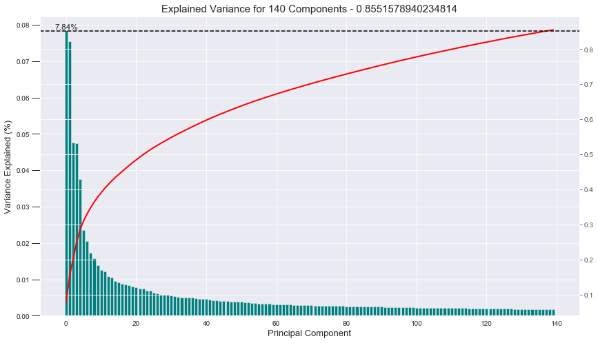

```python
scree_plot(pca)
```

```python
%%time
from sklearn.cluster import KMeans

def fetch_score(data, center):
    kmeans = KMeans(n_clusters=center, random_state=42)
    km_model = kmeans.fit(data)
    score = abs(km_model.score(data))
    return(score)


scores = []
for i in range(2, 28, 2):
    s = fetch_score(df_pca_sub, i)
    scores.append(s)
    print('i: {}, s: {}'.format(i,s))
```

```
i: 2, s: 32107795.638559457
i: 4, s: 28756856.173699785
i: 6, s: 27532434.127998006
i: 8, s: 26771138.79778634
i: 10, s: 26212247.46915828
i: 12, s: 25804769.57756966
i: 14, s: 25468221.86747202
i: 16, s: 25210328.93755425
i: 18, s: 24997205.38342546
i: 20, s: 24780420.427106295
i: 22, s: 24549395.26688052
i: 24, s: 24316974.036438864
i: 26, s: 24142343.215039134
Wall time: 24min 51s
Parser   : 512 ms
```

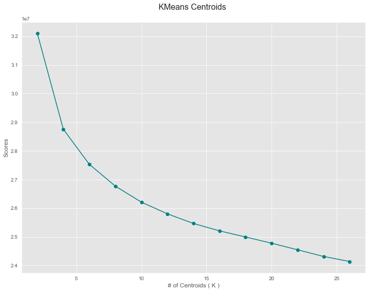

```python
plt.figure(figsize=(12,9))
centers = [2,4,6,8,10,12,14,16,18,20,22,24,26]
plt.plot(centers, scores, linestyle='-', marker='o', color='teal')
plt.title('KMeans Centroids \n', size=16 )
plt.xlabel('# of Centroids ( K )')
plt.ylabel('Scores')
#plt.show()
plt.savefig('kmeans')
```

```python
%%time
df_pca_sub = df_pca[np.random.choice(df_pca.shape[0], 120000, replace=False),:]
df_pca_sub.shape
```

```
Wall time: 4min 52s
```

```
(120000, 140)
```

```python
%%time
# Re-fit and predict the k-means model with the selected 14 clusters
kmeans = KMeans(n_clusters=14)
pop_predict = kmeans.fit_predict(df_pca)
```

```
Wall time: 15min 9s
Parser   : 114 ms
```

```python
customers_preprocessed = pd.read_csv('arvato_data/CUSTOMERS_cleaned.csv', sep=';')
customers_preprocessed.drop(customers_preprocessed.columns[0], axis=1, inplace=True)
customers_preprocessed
```

|  | AGER_TYP | AKT_DAT_KL | ALTER_HH | ANZ_HAUSHALTE_AKTIV | ANZ_HH_TITEL | ANZ_KINDER | ANZ_PERSONEN | ANZ_TITEL | ARBEIT | BALLRAUM | ... | VHN | VK_DHT4A | VK_DISTANZ | VK_ZG11 | W_KEIT_KIND_HH | WOHNDAUER_2008 | WOHNLAGE | ZABEOTYP | ANREDE_KZ | ALTERSKATEGORIE_GROB |
| --- | --- | --- | --- | --- | --- | --- | --- | --- | --- | --- | --- | --- | --- | --- | --- | --- | --- | --- | --- | --- | --- |
| 0 | 0.914267 | -0.369655 | -0.212081 | -0.281147 | -0.127196 | -0.264751 | -0.202478 | -0.134442 | -1.817040 | -0.611956 | ... | 0.502318 | 0.223609 | -0.518992 | -0.498829 | 0.871836 | 0.278574 | 1.584820 | 0.457019 | -0.701918 | 0.650473 |
| 1 | -1.360120 | -0.369655 | -0.850827 | -0.281147 | -0.127196 | -0.264751 | -0.916295 | -0.134442 | 0.166624 | 1.277512 | ... | 1.378005 | 1.925671 | 2.941938 | 3.566436 | 0.871836 | 0.278574 | -0.837562 | 0.457019 | 1.424668 | 0.650473 |
| 2 | 0.156138 | -0.369655 | -0.531454 | -0.352841 | -0.127196 | -0.264751 | -1.630112 | -0.134442 | -1.817040 | 1.277512 | ... | -0.373368 | 0.564022 | -0.172899 | -0.498829 | 0.871836 | 0.278574 | 1.584820 | -1.075715 | -0.701918 | 0.650473 |
| 3 | -1.360120 | -0.369655 | 1.384786 | 0.149018 | -0.127196 | -0.264751 | 1.225156 | -0.134442 | 0.166624 | -0.611956 | ... | 1.378005 | -0.457215 | 0.173194 | 0.404563 | -1.245470 | 0.278574 | -0.353086 | -1.075715 | -0.701918 | -0.671131 |
| 4 | 0.156138 | -0.369655 | -0.052394 | -0.281147 | -0.127196 | -0.264751 | -0.202478 | -0.134442 | 0.166624 | 1.277512 | ... | 1.378005 | -1.138040 | -0.865085 | -0.950525 | 0.871836 | 0.278574 | -1.322039 | -0.309348 | -0.701918 | -0.671131 |
| ... | ... | ... | ... | ... | ... | ... | ... | ... | ... | ... | ... | ... | ... | ... | ... | ... | ... | ... | ... | ... | ... |
| 135046 | 0.156138 | -0.369655 | -0.371767 | -0.281147 | -0.127196 | -0.264751 | -0.916295 | -0.134442 | 0.166624 | -1.556690 | ... | 1.378005 | 1.244846 | 1.211473 | 0.856260 | 0.871836 | 0.278574 | -1.322039 | 0.457019 | -0.701918 | -0.671131 |
| 135047 | -1.360120 | 0.150206 | -1.808947 | -0.352841 | -0.127196 | -0.264751 | -1.630112 | -0.134442 | -1.817040 | 0.805145 | ... | -0.373368 | 1.925671 | 0.865380 | 0.404563 | 0.871836 | 0.278574 | -0.353086 | 0.457019 | 1.424668 | 0.650473 |
| 135048 | 0.914267 | -0.369655 | 0.586353 | -0.281147 | -0.127196 | -0.264751 | 0.511339 | -0.134442 | 0.166624 | 1.277512 | ... | -1.249055 | 1.244846 | 1.211473 | 0.856260 | -0.716144 | 0.278574 | -0.353086 | 0.457019 | -0.701918 | 0.650473 |
| 135049 | 1.672396 | -0.369655 | 0.266979 | -0.066065 | -0.127196 | -0.264751 | 1.225156 | -0.134442 | 0.166624 | -0.611956 | ... | 0.502318 | -1.138040 | -1.211178 | -0.950525 | -0.186817 | 0.278574 | -0.837562 | 0.457019 | 1.424668 | -0.671131 |
| 135050 | 1.672396 | -0.369655 | -1.808947 | -0.281147 | -0.127196 | -0.264751 | 0.511339 | -0.134442 | -1.817040 | -0.611956 | ... | -1.249055 | -1.138040 | -1.211178 | -0.950525 | -0.716144 | 0.278574 | 1.584820 | -1.075715 | -0.701918 | -1.992736 |

135051 rows × 343 columns

```python
%%time
# Transform the customer data with the PCA and KMeans models trained on the population data
customers_pca = pca.transform(customers_preprocessed)
prediction_customers = kmeans.predict(customers_pca)
```

```
Wall time: 20.3 s
```

```python
#prepare the customer clusters for plotting; get percentage and counts
customer_cluster = pd.DataFrame({'cluster':prediction_customers})
customer_counts = customer_cluster.groupby(['cluster']).size().reset_index(name='counts')
customer_counts['percent'] = customer_counts['counts']/customer_cluster.shape[0]*100
customer_counts['type'] = 'Customers'
t_df=pd.DataFrame({'cluster':list(range(14)), 'counts':[0]*14, 'percent':[0]*14})
customer_counts = pd.merge(customer_counts,t_df, on='cluster', how='right').fillna(0)

#prepare the customer clusters for plotting; get percentage and counts
global_cluster = pd.DataFrame({'cluster':pop_predict})
global_counts = global_cluster.groupby(['cluster']).size().reset_index(name='counts')
global_counts['percent'] = global_counts['counts']/global_cluster.shape[0]*100
global_counts['type'] = 'Population'

t_df=pd.DataFrame({'cluster':list(range(14)), 'counts':[0]*14, 'percent':[0]*14})
global_counts = pd.merge(global_counts,t_df, on='cluster', how='right').fillna(0)
customer_counts = plot_df.append(gc_temp)
```

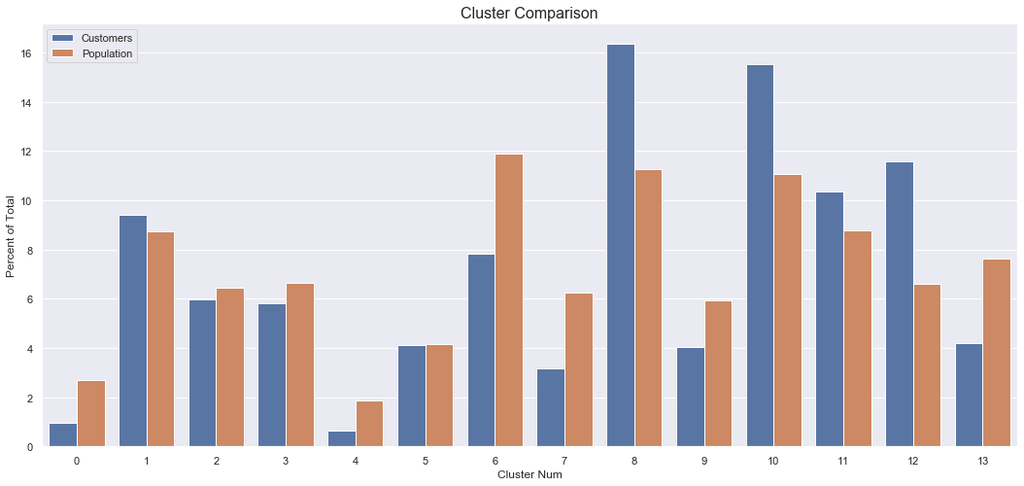

```python
plt.figure(figsize=(18,8))
sns.barplot(x='cluster', y='percent_x', hue='type', data=plot_df)
plt.title("Cluster Comparison", size=16)
plt.ylabel('Percent of Total')
plt.xlabel('Cluster Num')

plt.legend(loc='upper left')
plt.savefig('clusters')
```

```python
def describe_cluster(df1,df2,cluster):

    df1_T = df1[df1['cluster']==cluster].describe().T.sort_values(by='50%',ascending=False)['50%']
    df2_T = df2[df2['cluster']==cluster].describe().T.sort_values(by='50%',ascending=False)['50%']
    df_concat = pd.concat([df1_T,df2_T],axis=1).dropna()
    df_concat.columns = ['population_median', 'customer_median']
    df_concat['difference'] = np.abs(df_concat.population_median - df_concat.customer_median)
    df_concat = df_concat.sort_values(by='difference', ascending=False)
    print(df_concat.head(10))

azdias_preprocessed['cluster'] = pop_predict
customers_preprocessed['cluster'] = prediction_customers

describe_cluster(azdias_preprocessed,customers_preprocessed,0)
describe_cluster(azdias_preprocessed,customers_preprocessed,6)
describe_cluster(azdias_preprocessed,customers_preprocessed,8)
describe_cluster(azdias_preprocessed,customers_preprocessed,12)
```

```
                      population_median  customer_median  difference
GREEN_AVANTGARDE              -0.531199         0.983527    1.514726
ZABEOTYP                       0.427243        -1.075715    1.502958
D19_BANKEN_GROSS               0.819077        -0.341749    1.160826
D19_GESAMT_ANZ_24              2.110764         1.198492    0.912273
CJT_TYP_6                     -0.301412         0.583731    0.885143
D19_HAUS_DEKO                 -0.493998         0.368367    0.862365
ALTERSKATEGORIE_GROB           0.164104        -0.671131    0.835236
FINANZ_VORSORGER              -0.322522         0.503517    0.826039
CJT_TYP_5                     -0.179239         0.623102    0.802341
KBA05_MOD8                    -0.258143         0.492972    0.751116
                   population_median  customer_median  difference
FINANZTYP                  -1.353541         0.430541    1.784081
ANREDE_KZ                   0.957594        -0.701918    1.659512
AKT_DAT_KL                  1.249407        -0.369655    1.619062
D19_SONSTIGE               -0.893557         0.651692    1.545248
VERS_TYP                   -0.569915         0.910566    1.480481
FINANZ_MINIMALIST          -0.746967         0.718502    1.465470
HEALTH_TYP                 -0.062607         1.259568    1.322175
RT_KEIN_ANREIZ              1.261977        -0.005341    1.267318
D19_KONSUMTYP_MAX           0.743361        -0.348789    1.092150
D19_KONSUMTYP               0.851068        -0.010221    0.861289
                   population_median  customer_median  difference
GEBURTSJAHR                -1.239735         0.670094    1.909829
ANREDE_KZ                   0.957594        -0.701918    1.659512
D19_SONSTIGE               -0.893557         0.651692    1.545248
KBA05_MAXAH                -0.258385         0.946920    1.205305
KBA13_CCM_3001             -1.061181         0.091313    1.152494
D19_KONSUMTYP_MAX           0.743361        -0.348789    1.092150
KBA05_ANTG1                -1.065787        -0.152652    0.913135
SEMIO_DOM                   0.231045        -0.647686    0.878731
D19_KONSUMTYP               0.851068        -0.010221    0.861289
RT_KEIN_ANREIZ             -0.856498        -0.005341    0.851157
                   population_median  customer_median  difference
CJT_TYP_3                  -0.922908         0.628304    1.551212
D19_SONSTIGE               -0.893557         0.651692    1.545248
AKT_DAT_KL                  0.975417        -0.369655    1.345072
KBA13_ANTG2                 0.221365         1.458947    1.237582
FINANZ_HAUSBAUER            0.584621         1.704184    1.119564
KBA05_MOD1                 -0.877979         0.231829    1.109809
RT_UEBERGROESSE            -0.001109        -1.108760    1.107651
D19_KONSUMTYP_MAX           0.743361        -0.348789    1.092150
KBA13_HALTER_45             0.912295        -0.082700    0.994995
KBA13_FIAT                 -0.131099         0.791021    0.922120
```

## Part 2: Supervised Learning Model

Now that you've found which parts of the population are more likely to be customers of the mail-order company, it's time to build a prediction model. Each of the rows in the "MAILOUT" data files represents an individual that was targeted for a mailout campaign. Ideally, we should be able to use the demographic information from each individual to decide whether or not it will be worth it to include that person in the campaign.

The "MAILOUT" data has been split into two approximately equal parts, each with almost 43 000 data rows. In this part, you can verify your model with the "TRAIN" partition, which includes a column, "RESPONSE", that states whether or not a person became a customer of the company following the campaign. In the next part, you'll need to create predictions on the "TEST" partition, where the "RESPONSE" column has been withheld.

```python
#Load and transform data
mailout_train = pd.read_csv('arvato_data/Udacity_MAILOUT_052018_TRAIN.csv', dtype={18:'str',19:'str'}, sep=';')
mailout_test = pd.read_csv('arvato_data/Udacity_MAILOUT_052018_TEST.csv', dtype={18:'str',19:'str'}, sep=';')


def preprocess_data(df):
#    print(mailout_train.info())

    df_na_dropped = df.dropna(thresh=330)

    train_labels = df_na_dropped['RESPONSE']
    df_na_dropped = df_na_dropped.drop(['RESPONSE'], axis=1)

    #    print(mailout_train_dropped.info())
    df_na_dropped.drop(drop_cols, axis=1, inplace=True)

    df_na_dropped.loc[:, 'OST_WEST_KZ'].replace({'W':0, 'O':1}, inplace=True);

    imp = SimpleImputer(missing_values=float("NaN"), strategy="most_frequent", copy = False)
    train_features = imp.fit_transform(df_na_dropped)

    s_scaler = StandardScaler()
    train_features = s_scaler.fit_transform(train_features)
    return(train_features, train_labels )
```

```python
print(mailout_train.shape)
print(mailout_train.info())
print(mailout_train.describe())
mailout_train_processed,train_label = preprocess_data(mailout_train)
```

```
(42962, 367)
<class 'pandas.core.frame.DataFrame'>
RangeIndex: 42962 entries, 0 to 42961
Columns: 367 entries, LNR to ALTERSKATEGORIE_GROB
dtypes: float64(267), int64(94), object(6)
memory usage: 120.3+ MB
None
                LNR      AGER_TYP    AKT_DAT_KL      ALTER_HH  ALTER_KIND1  \
count  42962.000000  42962.000000  35993.000000  35993.000000  1988.000000
mean   42803.120129      0.542922      1.525241     10.285556    12.606137
std    24778.339984      1.412924      1.741500      6.082610     3.924976
min        1.000000     -1.000000      1.000000      0.000000     2.000000
25%    21284.250000     -1.000000      1.000000      8.000000     9.000000
50%    42710.000000      1.000000      1.000000     10.000000    13.000000
75%    64340.500000      2.000000      1.000000     15.000000    16.000000
max    85795.000000      3.000000      9.000000     21.000000    18.000000

       ALTER_KIND2  ALTER_KIND3  ALTER_KIND4  ALTERSKATEGORIE_FEIN  \
count   756.000000   174.000000    41.000000          34807.000000
mean     13.783069    14.655172    14.195122              9.855058
std       3.065817     2.615329     3.034959              4.373539
min       5.000000     6.000000     6.000000              0.000000
25%      12.000000    13.000000    13.000000              8.000000
50%      14.000000    15.000000    15.000000             10.000000
75%      16.000000    17.000000    17.000000             13.000000
max      18.000000    18.000000    18.000000             25.000000

       ANZ_HAUSHALTE_AKTIV  ...      VK_DHT4A    VK_DISTANZ       VK_ZG11  \
count         35185.000000  ...  35695.000000  35695.000000  35695.000000
mean              6.706096  ...      4.318644      4.505953      3.116963
std              15.151790  ...      3.165199      3.289502      2.534331
min               0.000000  ...      1.000000      1.000000      1.000000
25%               1.000000  ...      1.000000      2.000000      1.000000
50%               2.000000  ...      3.000000      4.000000      2.000000
75%               7.000000  ...      7.000000      7.000000      4.000000
max             438.000000  ...     11.000000     13.000000     11.000000

       W_KEIT_KIND_HH  WOHNDAUER_2008      WOHNLAGE      ZABEOTYP  \
count    33284.000000    35993.000000  35185.000000  42962.000000
mean         4.488403        8.729947      4.059685      2.804199
std          1.889573        1.010545      2.046697      1.121585
min          0.000000        1.000000      0.000000      1.000000
25%          3.000000        9.000000      3.000000      3.000000
50%          6.000000        9.000000      3.000000      3.000000
75%          6.000000        9.000000      7.000000      3.000000
max          6.000000        9.000000      8.000000      6.000000

           RESPONSE     ANREDE_KZ  ALTERSKATEGORIE_GROB
count  42962.000000  42962.000000          42962.000000
mean       0.012383      1.595084              3.213910
std        0.110589      0.490881              1.067475
min        0.000000      1.000000              1.000000
25%        0.000000      1.000000              3.000000
50%        0.000000      2.000000              4.000000
75%        0.000000      2.000000              4.000000
max        1.000000      2.000000              9.000000

[8 rows x 361 columns]
```

```python
t1 = temp.groupby(['D19_SOZIALES', 'RESPONSE'])['LNR'].count()
t1 = t1.reset_index(name='counts')
t1
```

|  | D19_SOZIALES | RESPONSE | counts |
| --- | --- | --- | --- |
| 0 | 0.0 | 0 | 6593 |
| 1 | 0.0 | 1 | 19 |
| 2 | 1.0 | 0 | 7351 |
| 3 | 1.0 | 1 | 269 |
| 4 | 2.0 | 0 | 1089 |
| 5 | 2.0 | 1 | 7 |
| 6 | 3.0 | 0 | 6424 |
| 7 | 3.0 | 1 | 20 |
| 8 | 4.0 | 0 | 2561 |
| 9 | 4.0 | 1 | 11 |
| 10 | 5.0 | 0 | 913 |
| 11 | 5.0 | 1 | 1 |

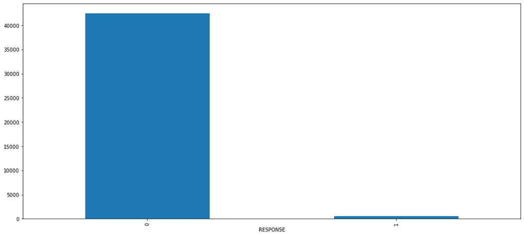

```python
mailout_train.groupby('RESPONSE')['LNR'].count().plot( x='LNR', kind='bar')
```

[figure not shown]

```python
sns.set_style("darkgrid")
plt.figure(figsize=(18,8))
sns.barplot(x='D19_SOZIALES', y='counts', hue='RESPONSE', data=t1)
plt.title("Cluster Comparison", size=16)
plt.ylabel('Percent of Total')
plt.xlabel('Cluster Num')

plt.legend(loc='upper left')
plt.savefig('clusters')
```

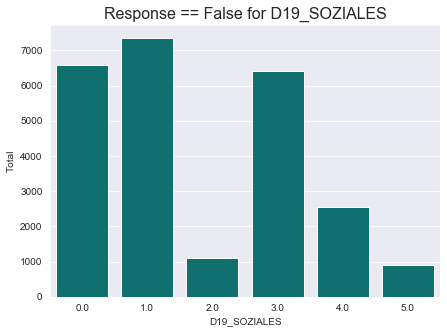

```python
#t1[t1['RESPONSE'] == 0][['D19_SOZIALES','counts']].plot(kind='bar', x='D19_SOZIALES', figsize=(7,5), color='y')
#t1[t1['RESPONSE'] == 1][['D19_SOZIALES','counts']].plot(kind='bar', x='D19_SOZIALES', figsize=(7,5), color='y')
sns.set_style("darkgrid")
plt.figure(figsize=(7,5))
sns.barplot(x='D19_SOZIALES', y='counts', color='teal', data=t1[t1['RESPONSE'] == 0][['D19_SOZIALES','counts']])
plt.title("Response == False for D19_SOZIALES", size=16)
plt.ylabel('Total')
plt.xlabel('D19_SOZIALES')
plt.savefig('D19_SOZIALES_false')
```

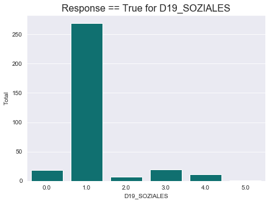

```python
plt.figure(figsize=(7,5))
sns.barplot(x='D19_SOZIALES', y='counts', color='teal', data=t1[t1['RESPONSE'] == 1][['D19_SOZIALES','counts']])
plt.title("Response == True for D19_SOZIALES", size=16)
plt.ylabel('Total')
plt.xlabel('D19_SOZIALES')
plt.savefig('D19_SOZIALES_true')
```

```python
print(mailout_test.shape)
print(mailout_test.info())
print(mailout_test.describe())
```

```
(42833, 366)
<class 'pandas.core.frame.DataFrame'>
RangeIndex: 42833 entries, 0 to 42832
Columns: 366 entries, LNR to ALTERSKATEGORIE_GROB
dtypes: float64(267), int64(93), object(6)
memory usage: 119.6+ MB
None
                LNR      AGER_TYP    AKT_DAT_KL      ALTER_HH  ALTER_KIND1  \
count  42833.000000  42833.000000  35944.000000  35944.000000  2013.000000
mean   42993.165620      0.537436      1.518890     10.239511    12.534029
std    24755.599728      1.414777      1.737441      6.109680     3.996079
min        2.000000     -1.000000      1.000000      0.000000     2.000000
25%    21650.000000     -1.000000      1.000000      8.000000     9.000000
50%    43054.000000      1.000000      1.000000     10.000000    13.000000
75%    64352.000000      2.000000      1.000000     15.000000    16.000000
max    85794.000000      3.000000      9.000000     21.000000    18.000000

       ALTER_KIND2  ALTER_KIND3  ALTER_KIND4  ALTERSKATEGORIE_FEIN  \
count   762.000000   201.000000    39.000000          34715.000000
mean     13.942257    14.442786    14.410256              9.822584
std       3.142155     2.787106     2.279404              4.410937
min       4.000000     6.000000     9.000000              0.000000
25%      12.000000    13.000000    13.000000              8.000000
50%      14.000000    15.000000    14.000000             10.000000
75%      17.000000    17.000000    16.000000             13.000000
max      18.000000    18.000000    18.000000             25.000000

       ANZ_HAUSHALTE_AKTIV  ...           VHN      VK_DHT4A    VK_DISTANZ  \
count         35206.000000  ...  34530.000000  35658.000000  35658.000000
mean              6.749986  ...      2.372401      4.308682      4.488474
std              14.839779  ...      1.151531      3.169149      3.274829
min               0.000000  ...      0.000000      1.000000      1.000000
25%               1.000000  ...      2.000000      1.000000      2.000000
50%               2.000000  ...      2.000000      3.000000      4.000000
75%               7.000000  ...      3.000000      7.000000      7.000000
max             379.000000  ...      4.000000     11.000000     13.000000

            VK_ZG11  W_KEIT_KIND_HH  WOHNDAUER_2008      WOHNLAGE  \
count  35658.000000    33214.000000    35944.000000  35206.000000
mean       3.090078        4.489282        8.727437      4.088280
std        2.510134        1.886903        1.013702      2.053977
min        1.000000        0.000000        1.000000      0.000000
25%        1.000000        3.000000        9.000000      3.000000
50%        2.000000        6.000000        9.000000      3.000000
75%        4.000000        6.000000        9.000000      7.000000
max       11.000000        6.000000        9.000000      8.000000

           ZABEOTYP     ANREDE_KZ  ALTERSKATEGORIE_GROB
count  42833.000000  42833.000000          42833.000000
mean       2.800037      1.595475              3.220484
std        1.120624      0.490806              1.069753
min        1.000000      1.000000              1.000000
25%        3.000000      1.000000              3.000000
50%        3.000000      2.000000              4.000000
75%        3.000000      2.000000              4.000000
max        6.000000      2.000000              9.000000

[8 rows x 360 columns]
```

```python
mailout_train_missing = mailout_train.isna().mean().round(4) * 100
mailout_train_missing.sort_values(inplace=True)
mailout_train_missing.tail(20)
# Number of Nans
temp_df = mailout_train.drop(drop_cols, axis=1)
mailout_missing_cols = temp_df.isna().sum()
mailout_missing_cols = mailout_missing_cols[mailout_missing_cols> 0]
mailout_missing_cols.index
#mailout_train_missing.sort_values(inplace=True)
#mailout_train_missing.tail(20)
print(type(mailout_missing_cols))
```

[output not shown]

```python
print(mailout_train['CAMEO_DEU_2015'].nunique())
print(mailout_train.iloc[22398, :20])
print(mailout_train['CAMEO_DEU_2015'].unique())
print(mailout_train['CAMEO_DEUG_2015'].unique())
print(mailout_train['CAMEO_INTL_2015'].unique())
#CUSTOMER_GROUP', 'ONLINE_PURCHASE', and 'PRODUCT_GROUP
mailout_train[mailout_train.eq('1994-03-23 00:00:00').any(1)]
print(mailout_train.iloc[42859, 80:130])
print(mailout_train['OST_WEST_KZ'].unique())
```

[output not shown]

```python
# RandomForest
rfc = RandomForestClassifier()

parameters = {
    "n_estimators":[450, 500, 550],
    "max_depth":[3, 4, 5],
    "min_samples_split":[4, 5, 6],
#    "min_samples_leaf":[2,4],
}

# n_estimators = [100, 300, 500, 800, 1200]
#max_depth = [5, 8, 15, 25, 30]
#min_samples_split = [2, 5, 10, 15, 100]
#min_samples_leaf = [1, 2, 5, 10]

cv = GridSearchCV(rfc,parameters,scoring='roc_auc', cv=5, verbose=5)
cv.fit(mailout_train_processed,train_label.values.ravel())
print(cv.best_params_)
print(cv.best_score_)
```

```
Fitting 5 folds for each of 27 candidates, totalling 135 fits
```

```
[Parallel(n_jobs=1)]: Using backend SequentialBackend with 1 concurrent workers.
```

```
[CV] max_depth=3, min_samples_split=4, n_estimators=450 ..............
[CV]  max_depth=3, min_samples_split=4, n_estimators=450, score=0.717, total=  21.4s
[CV] max_depth=3, min_samples_split=4, n_estimators=450 ..............
```

```
[Parallel(n_jobs=1)]: Done   1 out of   1 | elapsed:   21.3s remaining:    0.0s
```

```
[CV]  max_depth=3, min_samples_split=4, n_estimators=450, score=0.701, total=  19.0s
[CV] max_depth=3, min_samples_split=4, n_estimators=450 ..............
```

```
[Parallel(n_jobs=1)]: Done   2 out of   2 | elapsed:   40.3s remaining:    0.0s
```

```
[CV]  max_depth=3, min_samples_split=4, n_estimators=450, score=0.776, total=  19.1s
[CV] max_depth=3, min_samples_split=4, n_estimators=450 ..............
```

```
[Parallel(n_jobs=1)]: Done   3 out of   3 | elapsed:   59.4s remaining:    0.0s
```

```
[CV]  max_depth=3, min_samples_split=4, n_estimators=450, score=0.737, total=  19.2s
[CV] max_depth=3, min_samples_split=4, n_estimators=450 ..............
```

```
[Parallel(n_jobs=1)]: Done   4 out of   4 | elapsed:  1.3min remaining:    0.0s
```

[output not shown]

[output cut: 206 more lines]

```
[CV]  max_depth=5, min_samples_split=6, n_estimators=500, score=0.771, total=  42.6s
[CV] max_depth=5, min_samples_split=6, n_estimators=500 ..............
[CV]  max_depth=5, min_samples_split=6, n_estimators=500, score=0.750, total=  48.8s
[CV] max_depth=5, min_samples_split=6, n_estimators=500 ..............
[CV]  max_depth=5, min_samples_split=6, n_estimators=500, score=0.785, total=  50.5s
[CV] max_depth=5, min_samples_split=6, n_estimators=550 ..............
[CV]  max_depth=5, min_samples_split=6, n_estimators=550, score=0.713, total=  57.8s
[CV] max_depth=5, min_samples_split=6, n_estimators=550 ..............
[CV]  max_depth=5, min_samples_split=6, n_estimators=550, score=0.730, total=  57.1s
[CV] max_depth=5, min_samples_split=6, n_estimators=550 ..............
[CV]  max_depth=5, min_samples_split=6, n_estimators=550, score=0.785, total=  46.1s
[CV] max_depth=5, min_samples_split=6, n_estimators=550 ..............
[CV]  max_depth=5, min_samples_split=6, n_estimators=550, score=0.743, total=  44.2s
[CV] max_depth=5, min_samples_split=6, n_estimators=550 ..............
[CV]  max_depth=5, min_samples_split=6, n_estimators=550, score=0.790, total=  48.8s
```

```
[Parallel(n_jobs=1)]: Done 135 out of 135 | elapsed: 100.2min finished
```

```
{'max_depth': 4, 'min_samples_split': 4, 'n_estimators': 500}
0.7563233140378026
```

```python
mailout_train_processed
sum(train_label.values)
sum(mailout_train['RESPONSE'])
```

```
532
```

```python
df = pd.DataFrame(mailout_train_processed)
df.info()
```

```
<class 'pandas.core.frame.DataFrame'>
RangeIndex: 34196 entries, 0 to 34195
Columns: 353 entries, 0 to 352
dtypes: float64(353)
memory usage: 92.1 MB
```

## Part 3: Kaggle Competition

Now that you've created a model to predict which individuals are most likely to respond to a mailout campaign, it's time to test that model in competition through Kaggle. If you click on the link [here](http://www.kaggle.com/t/21e6d45d4c574c7fa2d868f0e8c83140), you'll be taken to the competition page where, if you have a Kaggle account, you can enter. If you're one of the top performers, you may have the chance to be contacted by a hiring manager from Arvato or Bertelsmann for an interview!

Your entry to the competition should be a CSV file with two columns. The first column should be a copy of "LNR", which acts as an ID number for each individual in the "TEST" partition. The second column, "RESPONSE", should be some measure of how likely each individual became a customer – this might not be a straightforward probability. As you should have found in Part 2, there is a large output class imbalance, where most individuals did not respond to the mailout. Thus, predicting individual classes and using accuracy does not seem to be an appropriate performance evaluation method. Instead, the competition will be using AUC to evaluate performance. The exact values of the "RESPONSE" column do not matter as much: only that the higher values try to capture as many of the actual customers as possible, early in the ROC curve sweep.

```python
X_train, X_test, y_train, y_test = train_test_split(mailout_train_processed, train_label, stratify=train_label, test_size=0.2)

rfc = RandomForestClassifier(max_depth = 4, min_samples_split=5, n_estimators=500)
rfc.fit(X_train,y_train)

#rfc.fit(mailout_train_processed,train_label.values.ravel())
```

```
RandomForestClassifier(bootstrap=True, ccp_alpha=0.0, class_weight=None,
                       criterion='gini', max_depth=4, max_features='auto',
                       max_leaf_nodes=None, max_samples=None,
                       min_impurity_decrease=0.0, min_impurity_split=None,
                       min_samples_leaf=1, min_samples_split=5,
                       min_weight_fraction_leaf=0.0, n_estimators=500,
                       n_jobs=None, oob_score=False, random_state=None,
                       verbose=0, warm_start=False)
```

```python
preds = rfc.predict_proba(X_test)

# Report the before-and-afterscores
print("Unoptimized model\n------")
print("ROC score on testing data: {:.4f}".format(roc_auc_score(y_test, preds[:,1])))
```

```
Unoptimized model
------
ROC score on testing data: 0.7281
```

```python
mailout_test.head(10)

#drop records with too many missing
#mailout_test_dropped = mailout_test.dropna(thresh=330)
mailout_test_dropped = mailout_test
# Save the LNR for result index
test_LNR = mailout_test_dropped['LNR']

#    print(mailout_train_dropped.info())
# Drop unneeded cols
mailout_test_dropped.drop(drop_cols, axis=1, inplace=True)
#mailout_test_dropped.drop(['RESPONSE'], axis=1, inplace=True)
mailout_test_dropped.loc[:, 'OST_WEST_KZ'].replace({'W':0, 'O':1}, inplace=True);

#impute NaNs
imp = SimpleImputer(missing_values=float("NaN"), strategy="most_frequent", copy = False)
test_features = imp.fit_transform(mailout_test_dropped)

s_scaler = StandardScaler()
test_features = s_scaler.fit_transform(test_features)
```

```python
# Prediction
rfc = RandomForestClassifier(max_depth = 4, min_samples_split=5, n_estimators=500)
rfc.fit(X_train,y_train)
preds = rfc.predict_proba(X_test)

test_label = rfc.predict_proba(test_features)[:,1]

submission = pd.DataFrame(test_label, index=test_LNR.astype('int32'),
                          columns=["RESPONSE"])

submission.head()

# Save file to submit
submission.to_csv('submission.csv')
```

```python
# Initial LGBMRegressor tests
reg = lgb.LGBMRegressor()

clf = lgb.LGBMRegressor(random_state=0, learning_rate=0.001, max_depth=8, n_estimators=1500, )
parameters = { 'num_leaves': [80, 100, 120, 140],
              'min_data_in_leaf': [12, 15, 20, 25]
             }


# Grid search it
cv = GridSearchCV(clf, parameters,scoring='roc_auc', cv=5, verbose=5, n_jobs=-1)

# Fit the ...
fitted = cv.fit(mailout_train_processed,train_label.values.ravel())


# Get the estimator and predict
print(cv.best_params_)
print(cv.best_score_)
```

```
Fitting 5 folds for each of 16 candidates, totalling 80 fits
```

```
[Parallel(n_jobs=-1)]: Using backend LokyBackend with 4 concurrent workers.
```

[output not shown]

[output cut: 57 more lines]

[output not shown]

```python
%%time
# Some basic training use LGBMRegressor

clf = lgb.LGBMRegressor(
            learning_rate=0.001,
            lambda_l2 = 0.1,
            random_state=0,
            max_depth=13,
            n_estimators=1900,
            min_data_in_leaf=20 )

parameters = {
            'num_leaves': [45, 50, 55]
             }

# Perform grid search on the classifier using 'scorer' as the scoring method
grid_obj = GridSearchCV(clf, parameters, scoring = 'roc_auc',  cv=5, verbose=10) # n_jobs=-1,

# Fit the grid search object to the training data and find the optimal parameters
grid_fit = grid_obj.fit(mailout_train_processed,train_label.values.ravel())

# Get the estimator and predict
print(grid_fit.best_estimator_)
print(grid_fit.best_params_)
print(grid_fit.best_score_)
```

```
Fitting 5 folds for each of 3 candidates, totalling 15 fits
[CV] num_leaves=45 ...................................................
```

```
[Parallel(n_jobs=1)]: Using backend SequentialBackend with 1 concurrent workers.
```

```
[CV] ....................... num_leaves=45, score=0.738, total= 2.1min
[CV] num_leaves=45 ...................................................
```

```
[Parallel(n_jobs=1)]: Done   1 out of   1 | elapsed:  2.1min remaining:    0.0s
```

```
[CV] ....................... num_leaves=45, score=0.777, total= 1.6min
[CV] num_leaves=45 ...................................................
```

```
[Parallel(n_jobs=1)]: Done   2 out of   2 | elapsed:  3.7min remaining:    0.0s
```

```
[CV] ....................... num_leaves=45, score=0.804, total= 2.2min
[CV] num_leaves=45 ...................................................
```

```
[Parallel(n_jobs=1)]: Done   3 out of   3 | elapsed:  5.9min remaining:    0.0s
```

```
[CV] ....................... num_leaves=45, score=0.765, total= 2.2min
[CV] num_leaves=45 ...................................................
```

```
[Parallel(n_jobs=1)]: Done   4 out of   4 | elapsed:  8.1min remaining:    0.0s
```

```
[CV] ....................... num_leaves=45, score=0.795, total= 2.2min
[CV] num_leaves=50 ...................................................
```

```
[Parallel(n_jobs=1)]: Done   5 out of   5 | elapsed: 10.3min remaining:    0.0s
```

```
[CV] ....................... num_leaves=50, score=0.743, total= 2.0min
[CV] num_leaves=50 ...................................................
```

```
[Parallel(n_jobs=1)]: Done   6 out of   6 | elapsed: 12.4min remaining:    0.0s
```

```
[CV] ....................... num_leaves=50, score=0.777, total= 1.8min
[CV] num_leaves=50 ...................................................
```

```
[Parallel(n_jobs=1)]: Done   7 out of   7 | elapsed: 14.2min remaining:    0.0s
```

```
[CV] ....................... num_leaves=50, score=0.800, total= 2.0min
[CV] num_leaves=50 ...................................................
```

```
[Parallel(n_jobs=1)]: Done   8 out of   8 | elapsed: 16.2min remaining:    0.0s
```

```
[CV] ....................... num_leaves=50, score=0.775, total= 1.7min
[CV] num_leaves=50 ...................................................
```

```
[Parallel(n_jobs=1)]: Done   9 out of   9 | elapsed: 18.0min remaining:    0.0s
```

```
[CV] ....................... num_leaves=50, score=0.801, total= 1.7min
[CV] num_leaves=55 ...................................................
[CV] ....................... num_leaves=55, score=0.735, total= 1.9min
[CV] num_leaves=55 ...................................................
[CV] ....................... num_leaves=55, score=0.779, total= 1.6min
[CV] num_leaves=55 ...................................................
[CV] ....................... num_leaves=55, score=0.799, total= 1.7min
[CV] num_leaves=55 ...................................................
[CV] ....................... num_leaves=55, score=0.770, total= 1.8min
[CV] num_leaves=55 ...................................................
[CV] ....................... num_leaves=55, score=0.799, total= 1.8min
```

```
[Parallel(n_jobs=1)]: Done  15 out of  15 | elapsed: 28.6min finished
```

```
LGBMRegressor(boosting_type='gbdt', class_weight=None, colsample_bytree=1.0,
              importance_type='split', lambda_l2=0.1, learning_rate=0.001,
              max_depth=13, min_child_samples=20, min_child_weight=0.001,
              min_data_in_leaf=20, min_split_gain=0.0, n_estimators=1900,
              n_jobs=-1, num_leaves=50, objective=None, random_state=0,
              reg_alpha=0.0, reg_lambda=0.0, silent=True, subsample=1.0,
              subsample_for_bin=200000, subsample_freq=0)
{'num_leaves': 50}
0.7792485355170605
Wall time: 30min 32s
```

```python
# Results from several hyperparameter tuning runs.
{'learning_rate': 0.001, 'max_depth': 10, 'n_estimators': 2000}
0.7738214439485253

{'min_data_in_leaf': 15, 'num_leaves': 80}
0.7663591334356443
```

```python
clf = lgb.LGBMRegressor(
            learning_rate=0.001,
            lambda_l2 = 0.1,
            random_state=0,
            max_depth=13,
            n_estimators=1900,
            min_data_in_leaf=20,
            num_leaves=50)

clf.fit(mailout_train_processed, train_label)
# Prediction
test_label = clf.predict(test_features)

submission = pd.DataFrame(test_label, index=test_LNR.astype('int32'),
                          columns=["RESPONSE"])
submission.head()

# Save file to submit
submission.to_csv('submission.csv')
```

```python
# Prediction
lgb_preds = test_label

rfc = RandomForestClassifier(max_depth = 4, min_samples_split=5, n_estimators=500)
rfc.fit(mailout_train_processed, train_label)
rf_preds = rfc.predict_proba(test_features)[:,1]
```

```python
print(lgb_preds)
print(rf_preds)
test_label = (rf_preds+lgb_preds)/2

submission = pd.DataFrame(test_label, index=test_LNR.astype('int32'),
                          columns=["RESPONSE"])

submission.head()

# Save file to submit
submission.to_csv('submission.csv')
```

```
[0.03163904 0.01598747 0.00379993 ... 0.00831696 0.04829675 0.03364624]
[0.01774926 0.01750166 0.01237377 ... 0.01357825 0.01087199 0.01260128]
```

```python
print(grid_fit.best_estimator_)
print(grid_fit.best_params_)
print(grid_fit.best_score_)
```

```
LGBMRegressor(boosting_type='gbdt', class_weight=None, colsample_bytree=1.0,
              importance_type='split', learning_rate=0.001, max_depth=10,
              min_child_samples=20, min_child_weight=0.001, min_split_gain=0.0,
              n_estimators=2000, n_jobs=-1, num_leaves=31, objective=None,
              random_state=0, reg_alpha=0.0, reg_lambda=0.0, silent=True,
              subsample=1.0, subsample_for_bin=200000, subsample_freq=0)
{'learning_rate': 0.001, 'max_depth': 10, 'n_estimators': 2000}
0.7738214439485253
```

```python
LGBMRegressor(boosting_type='gbdt', class_weight=None, colsample_bytree=1.0,
              importance_type='split', lambda_l2=0.1, learning_rate=0.001,
              max_depth=12, min_child_samples=20, min_child_weight=0.001,
              min_split_gain=0.0, n_estimators=2000, n_jobs=-1, num_leaves=31,
              objective=None, random_state=0, reg_alpha=0.0, reg_lambda=0.0,
              silent=True, subsample=1.0, subsample_for_bin=200000,
              subsample_freq=0)
{'max_depth': 12, 'n_estimators': 2000}
0.7748209259235634
Wall time: 1h 3min 38s

LGBMRegressor(boosting_type='gbdt', class_weight=None, colsample_bytree=1.0,
              importance_type='split', lambda_l2=0.1, learning_rate=0.001,
              max_depth=13, min_child_samples=20, min_child_weight=0.001,
              min_split_gain=0.0, n_estimators=1900, n_jobs=-1, num_leaves=31,
              objective=None, random_state=0, reg_alpha=0.0, reg_lambda=0.0,
              silent=True, subsample=1.0, subsample_for_bin=200000,
              subsample_freq=0)
{'max_depth': 13, 'n_estimators': 1900}
0.7778164928266607
Wall time: 1h 7min 34s

LGBMRegressor(boosting_type='gbdt', class_weight=None, colsample_bytree=1.0,
              importance_type='split', lambda_l2=0.1, learning_rate=0.001,
              max_depth=13, min_child_samples=20, min_child_weight=0.001,
              min_data_in_leaf=20, min_split_gain=0.0, n_estimators=1900,
              n_jobs=-1, num_leaves=31, objective=None, random_state=0,
              reg_alpha=0.0, reg_lambda=0.0, silent=True, subsample=1.0,
              subsample_for_bin=200000, subsample_freq=0)
{'min_data_in_leaf': 20}
0.7778164928266607
Wall time: 24min 20s

LGBMRegressor(boosting_type='gbdt', class_weight=None, colsample_bytree=1.0,
              importance_type='split', lambda_l2=0.1, learning_rate=0.001,
              max_depth=13, min_child_samples=20, min_child_weight=0.001,
              min_data_in_leaf=20, min_split_gain=0.0, n_estimators=1900,
              n_jobs=-1, num_leaves=50, objective=None, random_state=0,
              reg_alpha=0.0, reg_lambda=0.0, silent=True, subsample=1.0,
              subsample_for_bin=200000, subsample_freq=0)
{'num_leaves': 50}
0.7792485355170605
Wall time: 27min 33s

LGBMRegressor(boosting_type='gbdt', class_weight=None, colsample_bytree=1.0,
              importance_type='split', lambda_l2=0.1, learning_rate=0.001,
              max_depth=13, min_child_samples=20, min_child_weight=0.001,
              min_data_in_leaf=20, min_split_gain=0.0, n_estimators=1900,
              n_jobs=-1, num_leaves=50, objective=None, random_state=0,
              reg_alpha=0.0, reg_lambda=0.0, silent=True, subsample=1.0,
              subsample_for_bin=200000, subsample_freq=0)
{'num_leaves': 50}
0.7792485355170605
Wall time: 30min 32s
```

```python
%%time
# training use XGBRegressor
xgbr = XGBRegressor(objective='binary:logistic',  learning_rate=0.1,
                    random_state=42, max_depth=3, min_child_weight=3,
                    n_estimators=100, gamma=0.0, subsample=0.6, colsample_bytree=0.7)

parameters = {
            'n_estimators':[95, 100, 105]
            #'learning_rate':[0.05, 0.06, 0.07, 0.08, 0.09, 0.1]
             }

# Perform grid search on the classifier using 'scorer' as the scoring method
gcv = GridSearchCV(xgbr, parameters, scoring = 'roc_auc',  cv=5, verbose=10) #, n_jobs=-1)

# Fit the grid search object to the training data and find the optimal parameters
gcv_fit = gcv.fit(mailout_train_processed,train_label.values.ravel())

# Get the estimator and predict
print(gcv_fit.best_estimator_)
print(gcv_fit.best_params_)
print(gcv_fit.best_score_)
```

```
Fitting 5 folds for each of 3 candidates, totalling 15 fits
[CV] n_estimators=95 .................................................
```

```
[Parallel(n_jobs=1)]: Using backend SequentialBackend with 1 concurrent workers.
```

```
[CV] ..................... n_estimators=95, score=0.757, total=  18.9s
[CV] n_estimators=95 .................................................
```

```
[Parallel(n_jobs=1)]: Done   1 out of   1 | elapsed:   18.8s remaining:    0.0s
```

```
[CV] ..................... n_estimators=95, score=0.775, total=  24.7s
[CV] n_estimators=95 .................................................
```

```
[Parallel(n_jobs=1)]: Done   2 out of   2 | elapsed:   43.5s remaining:    0.0s
```

```
[CV] ..................... n_estimators=95, score=0.817, total=  20.8s
[CV] n_estimators=95 .................................................
```

```
[Parallel(n_jobs=1)]: Done   3 out of   3 | elapsed:  1.1min remaining:    0.0s
```

```
[CV] ..................... n_estimators=95, score=0.788, total=  22.8s
[CV] n_estimators=95 .................................................
```

```
[Parallel(n_jobs=1)]: Done   4 out of   4 | elapsed:  1.5min remaining:    0.0s
```

```
[CV] ..................... n_estimators=95, score=0.785, total=  20.7s
[CV] n_estimators=100 ................................................
```

```
[Parallel(n_jobs=1)]: Done   5 out of   5 | elapsed:  1.8min remaining:    0.0s
```

```
[CV] .................... n_estimators=100, score=0.761, total=  21.5s
[CV] n_estimators=100 ................................................
```

```
[Parallel(n_jobs=1)]: Done   6 out of   6 | elapsed:  2.2min remaining:    0.0s
```

```
[CV] .................... n_estimators=100, score=0.774, total=  20.4s
[CV] n_estimators=100 ................................................
```

```
[Parallel(n_jobs=1)]: Done   7 out of   7 | elapsed:  2.5min remaining:    0.0s
```

```
[CV] .................... n_estimators=100, score=0.815, total=  20.8s
[CV] n_estimators=100 ................................................
```

```
[Parallel(n_jobs=1)]: Done   8 out of   8 | elapsed:  2.8min remaining:    0.0s
```

```
[CV] .................... n_estimators=100, score=0.784, total=  20.6s
[CV] n_estimators=100 ................................................
```

```
[Parallel(n_jobs=1)]: Done   9 out of   9 | elapsed:  3.2min remaining:    0.0s
```

```
[CV] .................... n_estimators=100, score=0.791, total=  20.4s
[CV] n_estimators=105 ................................................
[CV] .................... n_estimators=105, score=0.759, total=  21.2s
[CV] n_estimators=105 ................................................
[CV] .................... n_estimators=105, score=0.772, total=  21.5s
[CV] n_estimators=105 ................................................
[CV] .................... n_estimators=105, score=0.818, total=  20.4s
[CV] n_estimators=105 ................................................
[CV] .................... n_estimators=105, score=0.779, total=  20.3s
[CV] n_estimators=105 ................................................
[CV] .................... n_estimators=105, score=0.790, total=  20.0s
```

```
[Parallel(n_jobs=1)]: Done  15 out of  15 | elapsed:  5.3min finished
```

```
XGBRegressor(base_score=0.5, booster=None, colsample_bylevel=1,
             colsample_bynode=1, colsample_bytree=0.7, gamma=0.0, gpu_id=-1,
             importance_type='gain', interaction_constraints=None,
             learning_rate=0.1, max_delta_step=0, max_depth=3,
             min_child_weight=3, missing=nan, monotone_constraints=None,
             n_estimators=100, n_jobs=0, num_parallel_tree=1,
             objective='binary:logistic', random_state=42, reg_alpha=0,
             reg_lambda=1, scale_pos_weight=1, subsample=0.6, tree_method=None,
             validate_parameters=False, verbosity=None)
{'n_estimators': 100}
0.7850574707646799
Wall time: 5min 39s
```

```python
# Results from XGBRegressor grid search runs
'learning_rate':[0.05, 0.06, 0.07, 0.08, 0.09, 0.1]
 XGBRegressor(base_score=0.5, booster=None, colsample_bylevel=1,
             colsample_bynode=1, colsample_bytree=0.7, gamma=0.0, gpu_id=-1,
             importance_type='gain', interaction_constraints=None,
             learning_rate=0.1, max_delta_step=0, max_depth=3,
             min_child_weight=3, missing=nan, monotone_constraints=None,
             n_estimators=100, n_jobs=0, num_parallel_tree=1,
             objective='binary:logistic', random_state=42, reg_alpha=0,
             reg_lambda=1, scale_pos_weight=1, subsample=0.6, tree_method=None,
             validate_parameters=False, verbosity=None)
{'learning_rate': 0.1}
0.7850574707646799
Wall time: 11min 16s

'subsample':[0.55, 0.6, 0.65],
'colsample_bytree':[0.65, 0.7, 0.75, 0.8]
XGBRegressor(base_score=0.5, booster=None, colsample_bylevel=1,
             colsample_bynode=1, colsample_bytree=0.7, gamma=0.0, gpu_id=-1,
             importance_type='gain', interaction_constraints=None,
             learning_rate=0.1, max_delta_step=0, max_depth=3,
             min_child_weight=3, missing=nan, monotone_constraints=None,
             n_estimators=100, n_jobs=0, num_parallel_tree=1,
             objective='binary:logistic', random_state=42, reg_alpha=0,
             reg_lambda=1, scale_pos_weight=1, subsample=0.6, tree_method=None,
             validate_parameters=False, verbosity=None)
{'colsample_bytree': 0.7, 'subsample': 0.6}
0.7850574707646799
Wall time: 20min 36s

'subsample':[0.5, 0.6, 0.7],
'colsample_bytree':[0.5, 0.6, 0.7]
XGBRegressor(base_score=0.5, booster=None, colsample_bylevel=1,
             colsample_bynode=1, colsample_bytree=0.7, gamma=0.0, gpu_id=-1,
             importance_type='gain', interaction_constraints=None,
             learning_rate=0.1, max_delta_step=0, max_depth=3,
             min_child_weight=3, missing=nan, monotone_constraints=None,
             n_estimators=100, n_jobs=0, num_parallel_tree=1,
             objective='binary:logistic', random_state=42, reg_alpha=0,
             reg_lambda=1, scale_pos_weight=1, subsample=0.6, tree_method=None,
             validate_parameters=False, verbosity=None)
{'colsample_bytree': 0.7, 'subsample': 0.6}
0.7850574707646799
Wall time: 14min 52s

'gamma':[0.0, 0.2, 0.4, 0.6]
XGBRegressor(base_score=0.5, booster=None, colsample_bylevel=1,
             colsample_bynode=1, colsample_bytree=1, gamma=0.0, gpu_id=-1,
             importance_type='gain', interaction_constraints=None,
             learning_rate=0.1, max_delta_step=0, max_depth=3,
             min_child_weight=3, missing=nan, monotone_constraints=None,
             n_estimators=100, n_jobs=0, num_parallel_tree=1,
             objective='binary:logistic', random_state=42, reg_alpha=0,
             reg_lambda=1, scale_pos_weight=1, subsample=1, tree_method=None,
             validate_parameters=False, verbosity=None)
{'gamma': 0.0}
0.777715514546973
Wall time: 9min 44s


parameters = {
            'max_depth':[3, 6, 10],
            'min_child_weight':[2, 4, 6]
             }

XGBRegressor(base_score=0.5, booster=None, colsample_bylevel=1,
             colsample_bynode=1, colsample_bytree=1, gamma=0, gpu_id=-1,
             importance_type='gain', interaction_constraints=None,
             learning_rate=0.09, max_delta_step=0, max_depth=3,
             min_child_weight=2, missing=nan, monotone_constraints=None,
             n_estimators=100, n_jobs=0, num_parallel_tree=1,
             objective='binary:logistic', random_state=42, reg_alpha=0,
             reg_lambda=1, scale_pos_weight=1, subsample=1, tree_method=None,
             validate_parameters=False, verbosity=None)
{'max_depth': 3, 'min_child_weight': 2}
0.7789512979471498
Wall time: 41min 19s

XGBRegressor(base_score=0.5, booster=None, colsample_bylevel=1,
             colsample_bynode=1, colsample_bytree=1, gamma=0, gpu_id=-1,
             importance_type='gain', interaction_constraints=None,
             learning_rate=0.09, max_delta_step=0, max_depth=6,
             min_child_weight=1, missing=nan, monotone_constraints=None,
             n_estimators=90, n_jobs=0, num_parallel_tree=1,
             objective='binary:logistic', random_state=42, reg_alpha=0,
             reg_lambda=1, scale_pos_weight=1, subsample=1, tree_method=None,
             validate_parameters=False, verbosity=None)
{'n_estimators': 90}
0.773693662969211
Wall time: 15min 18s
```

```python
xgbr = XGBRegressor(objective='binary:logistic',  learning_rate=0.1,
                    random_state=42, max_depth=3, min_child_weight=3,
                    n_estimators=100, gamma=0.0, subsample=0.6, colsample_bytree=0.7)

xgbr.fit(mailout_train_processed, train_label)
# Prediction
test_label = xgbr.predict(test_features)

submission = pd.DataFrame(test_label, index=test_LNR.astype('int32'),
                          columns=["RESPONSE"])
submission.head()

# Save file to submit
submission.to_csv('submission.csv')
```

```python
xgbr_preds = test_label

clf = lgb.LGBMRegressor(
            learning_rate=0.001,
            lambda_l2 = 0.1,
            random_state=0,
            max_depth=13,
            n_estimators=1900,
            min_data_in_leaf=20,
            num_leaves=50)

clf.fit(mailout_train_processed, train_label)
# Prediction
lgb_preds = clf.predict(test_features)

rfc = RandomForestClassifier(max_depth = 4, min_samples_split=5, n_estimators=500)
rfc.fit(mailout_train_processed, train_label)
rf_preds = rfc.predict_proba(test_features)[:,1]

print(lgb_preds)
print(rf_preds)
print(xgbr_preds)
test_label = (xgbr_preds+rf_preds+lgb_preds)/3

submission = pd.DataFrame(test_label, index=test_LNR.astype('int32'),
                          columns=["RESPONSE"])
submission.head()
```

```
[0.03163904 0.01598747 0.00379993 ... 0.00831696 0.04829675 0.03364624]
[0.01813488 0.01706819 0.01552554 ... 0.01252018 0.01151781 0.01394867]
[0.05178991 0.01550879 0.00361368 ... 0.01679283 0.02336414 0.01460921]
```

| LNR | RESPONSE |
| --- | --- |
| 1754 | 0.033855 |
| 1770 | 0.016188 |
| 1465 | 0.007646 |
| 1470 | 0.006589 |
| 1478 | 0.007019 |

```python
# Save file to submit
submission.to_csv('submission.csv')
```